# 41023224L李姿瑾_FinalReport

2025-06-02

```r
school_sf <- st_read("./DATA/SCHOOL/SCHOOL.shp",options = "encoding=Big5" )
Vill_sf <- st_read("./DATA/Taipei_Vill/Taipei_Vill.shp",options = "encoding=Big5" )
FF_sf <- st_read("./DATA/Tpe_Fastfood/Tpe_Fastfood.shp",options = "encoding=Big5" )
```

### Part 1:不同行政區的速食店有不同的地理分布特徵嗎？

#### 實作題

##### 1.

> p >= 0.05，無法拒絕虛無假設，表示無顯著差異。

```r
FF_vill_sf <- st_join(FF_sf, Vill_sf, join = st_within, left = FALSE)
```

```r
a_ff <- FF_vill_sf %>%
  filter(TOWN %in% c("文山區", "大安區", "中正區"))

# B區：信義、南港、松山
b_ff <- FF_vill_sf %>%
  filter(TOWN %in% c("信義區", "南港區", "松山區"))
```

```r
a_buffer <- st_buffer(a_ff, dist = 1000)
b_buffer <- st_buffer(b_ff, dist = 1000)

a_school_counts <- sapply(1:nrow(a_buffer), function(i) {
  sum(st_intersects(a_buffer[i,], school_sf, sparse = FALSE))
})

b_school_counts <- sapply(1:nrow(b_buffer), function(i) {
  sum(st_intersects(b_buffer[i,], school_sf, sparse = FALSE))
})

t_result <- t.test(a_school_counts, b_school_counts, var.equal = FALSE)

cat("統計檢定摘要\n")
```

```
統計檢定摘要
```

```r
cat("虛無假設 H₀：A區與B區速食店涵蓋學校數平均值無差異\n")
```

```
虛無假設 H₀：A區與B區速食店涵蓋學校數平均值無差異
```

```r
cat("對立假設 H₁：A區與B區速食店涵蓋學校數平均值有差異\n")
```

```
對立假設 H₁：A區與B區速食店涵蓋學校數平均值有差異
```

```r
cat("A區平均學校數：", mean(a_school_counts), "\n")
```

```
A區平均學校數： 3.870968
```

```r
cat("B區平均學校數：", mean(b_school_counts), "\n")
```

```
B區平均學校數： 3.318182
```

```r
cat("t 值：", round(t_result$statistic, 3), "\n")
```

```
t 值： 1.598
```

```r
cat("p 值：", round(t_result$p.value, 4), "\n")
```

```
p 值： 0.1163
```

```r
if(t_result$p.value < 0.05){
  cat("結果：p < 0.05，拒絕虛無假設，表示 A區與B區涵蓋學校數量有顯著差異。\n")
} else {
  cat("結果：p >= 0.05，無法拒絕虛無假設，表示無顯著差異。\n")
}
```

```
結果：p >= 0.05，無法拒絕虛無假設，表示無顯著差異。
```

##### 2.

```r
grid <- st_make_grid(Vill_sf, cellsize = 500, square = TRUE)
grid_sf <- st_sf(grid_id = 1:length(grid), geometry = grid)

ff_count <- st_join(grid_sf, FF_sf, join = st_contains) %>%
  group_by(grid_id) %>%
  summarise(count = n()) %>%
  st_as_sf()
View(school_sf)
View(school_sf)

nb <- poly2nb(ff_count, queen = TRUE)
lw <- nb2listw(nb, style = "W")

correlog <- sp.correlogram(nb, ff_count$count, order = 10,
                           method = "I", style = "W", zero.policy = TRUE)
```

```r
correlog_mat <- matrix(unlist(correlog$res), ncol = 5, byrow = TRUE)
correlog_df <- as.data.frame(correlog_mat)
colnames(correlog_df) <- c("lag", "I", "expected", "sd", "p.value")

plot(correlog_df$lag, correlog_df$I, type = "b",
     xlab = "distance classes", ylab = "Moran I statistic",
     ylim = c(min(correlog_df$I) - 0.05, max(correlog_df$I) + 0.05))

abline(h = 0, lty = 2)
```

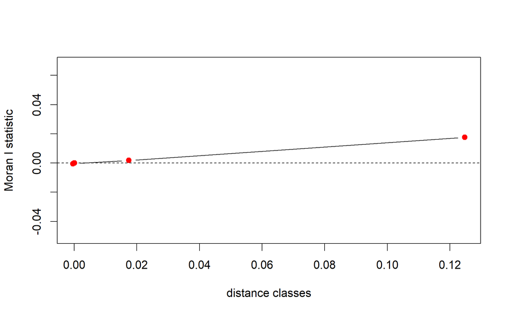

```r
sig_lags <- correlog_df$p.value < 0.05
points(correlog_df$lag[sig_lags], correlog_df$I[sig_lags],
       col = "red", pch = 19)
```

##### 3.

```r
grid_sf$count_ff <- ff_count$count
grid_sf$count_school <- st_join(grid_sf, school_sf, join = st_contains) %>%
  group_by(grid_id) %>%
  summarise(count = n()) %>%
  pull(count)

grid_sf$count_school[is.na(grid_sf$count_school)] <- 0  # 替代 NA 為 0

nb <- poly2nb(grid_sf, queen = TRUE)
lw <- nb2listw(nb, style = "W")

gi_ff <- localG(grid_sf$count_ff, lw)
gi_school <- localG(grid_sf$count_school, lw)

p_ff <- 2 * pnorm(-abs(gi_ff))
p_school <- 2 * pnorm(-abs(gi_school))

p_ff_fdr <- p.adjust(p_ff, method = "fdr")
p_school_fdr <- p.adjust(p_school, method = "fdr")

grid_sf$ff_hotspot <- ifelse(p_ff_fdr < 0.05, gi_ff, 0)
grid_sf$school_hotspot <- ifelse(p_school_fdr < 0.05, gi_school, 0)
```

[output not shown]

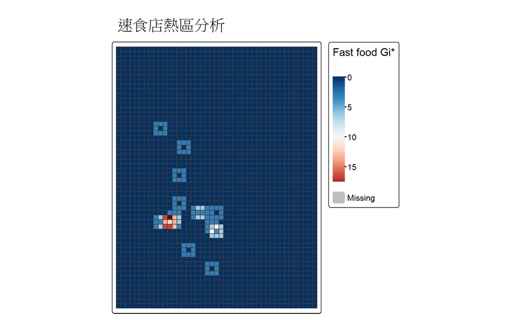

```r
tm_shape(grid_sf) +
  tm_fill("ff_hotspot", palette = "-RdBu", title = "Fast food Gi*",
          style = "cont", midpoint = NA) +
  tm_borders() +
  tm_layout(main.title = "速食店熱區分析", legend.outside = TRUE)
```

[output not shown]

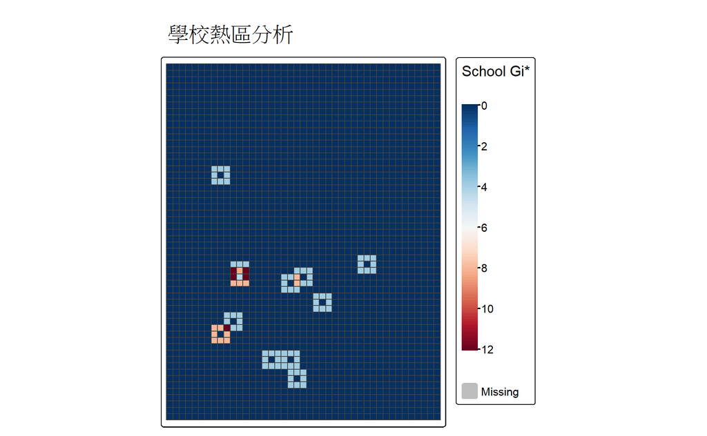

```r
tm_shape(grid_sf) +
  tm_fill("school_hotspot", palette = "-RdBu", title = "School Gi*",
          style = "cont", midpoint = NA) +
  tm_borders() +
  tm_layout(main.title = "學校熱區分析", legend.outside = TRUE)
```

### Part2 學校附近的速食店數量真的比較多嗎?

#### 實作題

##### 1.

```r
SH_vill_sf <- st_join(school_sf, Vill_sf, join = st_within, left = FALSE)
```

```r
school_da <- SH_vill_sf %>% filter(TOWN == "大安區")
school_ws <- SH_vill_sf %>% filter(TOWN == "文山區")
school_xy <- SH_vill_sf %>% filter(TOWN == "信義區")
```

```r
min_dist <- function(school_pts, fastfood_pts) {
  dists <- st_distance(school_pts, fastfood_pts)
  apply(dists, 1, min) %>% as.numeric()
}

dist_da <- min_dist(school_da, FF_sf)
dist_ws <- min_dist(school_ws, FF_sf)
dist_xy <- min_dist(school_xy, FF_sf)
```

```r
d_range <- seq(0, 2000, by = 10)

get_Fd <- function(dist_vec, d_range) {
  sapply(d_range, function(d) mean(dist_vec <= d))
}

Fd_da <- get_Fd(dist_da, d_range)
Fd_ws <- get_Fd(dist_ws, d_range)
Fd_xy <- get_Fd(dist_xy, d_range)

plot(d_range, Fd_da, type = "l", col = "blue", lwd = 3,
     xlab = "Distance (m)", ylab = "Cumulative Proportion",
     main = "F(d): 學校到速食店距離累積分布", ylim = c(0, 1))

lines(d_range, Fd_ws, col = "green", lwd = 3)
```

```r
lines(d_range, Fd_xy, col = "red", lwd = 3)

text(2000, Fd_da[length(Fd_da)], "大安區", col = "blue", pos = 4)
```

```r
text(2000, Fd_ws[length(Fd_ws)], "文山區", col = "green", pos = 4)
text(2000, Fd_xy[length(Fd_xy)], "信義區", col = "red", pos = 4)
```

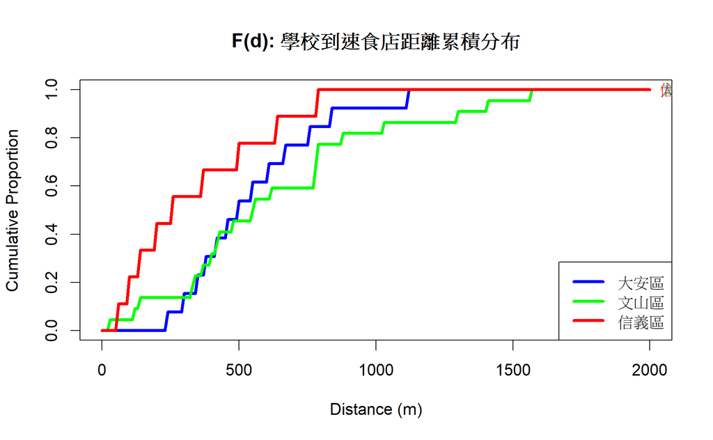

```r
legend("bottomright", legend = c("大安區", "文山區", "信義區"),
       col = c("blue", "green", "red"), lty = 1, lwd = 3)
```

##### 2.

```r
ff_sp <- st_transform(FF_sf, 3826)
win <- as.owin(st_bbox(ff_sp))
coords <- st_coordinates(ff_sp)
pp <- ppp(x = coords[,1], y = coords[,2], window = win)
```

```r
Kest_result <- Kest(pp, r = seq(0, 3000, by = 100), correction = "Ripley")

Lest_result <- Lest(pp, r = seq(0, 3000, by = 100), correction = "Ripley")

envelope_result <- envelope(pp, fun = Lest, nsim = 99, rank = 1,
                            correction = "Ripley", r = seq(0, 3000, by = 100))
```

```
Generating 99 simulations of CSR  ...
1, 2, 3, 4, 5, 6, 7, 8, 9, 10, 11, 12, 13, 14, 15, 16, 17, 18, 19, 20, 21, 22, 23, 24, 25, 26, 27,
28, 29, 30, 31, 32, 33, 34, 35, 36, 37, 38, 39, 40, 41, 42, 43, 44, 45, 46, 47, 48, 49, 50, 51, 52, 53, 54,
55, 56, 57, 58, 59, 60, 61, 62, 63, 64, 65, 66, 67, 68, 69, 70, 71, 72, 73, 74, 75, 76, 77, 78, 79, 80, 81,
82, 83, 84, 85, 86, 87, 88, 89, 90, 91, 92, 93, 94, 95, 96, 97, 98,
99.

Done.
```

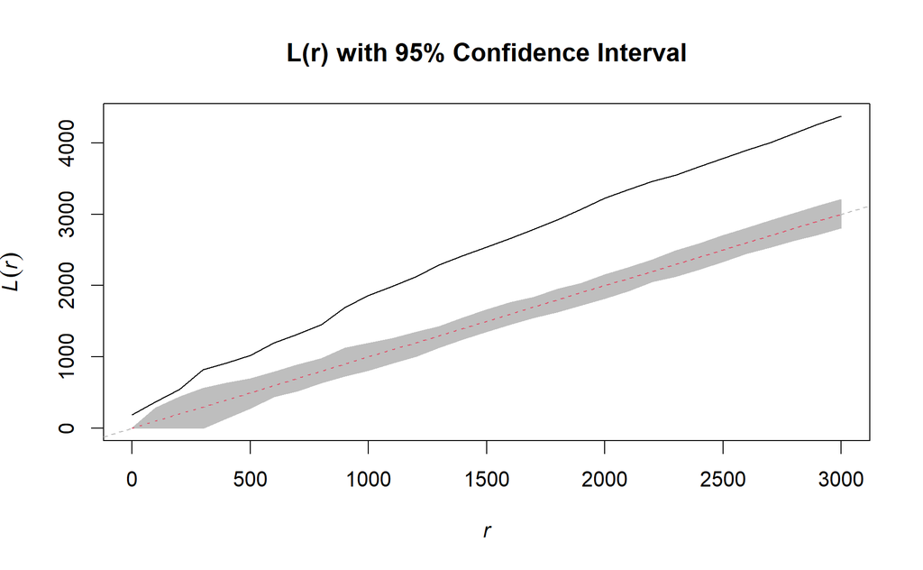

```r
plot(envelope_result, main = "L(r) with 95% Confidence Interval",
     legend = FALSE)
abline(a = 0, b = 1, lty = 2, col = "gray")
```

```r
K3000 <- Kest_result$iso[which(Kest_result$r == 3000)]
L3000 <- Lest_result$iso[which(Lest_result$r == 3000)]
L3000_lo <- envelope_result$lo[which(envelope_result$r == 3000)]
L3000_hi <- envelope_result$hi[which(envelope_result$r == 3000)]

cat("K(3000)：", K3000, "\n")
```

```
K(3000)： 60111493
```

```r
cat("L(3000)：", L3000, "\n")
```

```
L(3000)： 4374.252
```

```r
cat("L(3000) 95% 信賴區間：", L3000_lo, "~", L3000_hi, "\n")
```

```
L(3000) 95% 信賴區間： 2810.895 ~ 3202.906
```

##### 3.

> Bivariate F function 分析公立與私立學校到速食店的空間可及性，並進一步結合 CSR（完全隨機分布）模擬，以顯著水準=0.05 檢定兩者是否有顯著差異。從第一張圖顯示，私立學校的 F(d) 累積曲線明顯快於公立學校，表示其在較短距離內即有較多速食店可達，可及性較高。為檢定此差異是否具統計意義，分別對私立與公立學校進行 CSR 模擬（第二與第三張圖）。

```r
school_public <- SH_vill_sf %>% filter(Type == "公立")
school_private <- SH_vill_sf %>% filter(Type == "私立")
```

```r
win <- as.owin(st_bbox(school_sf))
coords_public <- st_coordinates(st_transform(school_public, 3826))
coords_private <- st_coordinates(st_transform(school_private, 3826))
coords_fastfood <- st_coordinates(st_transform(FF_sf, 3826))

pp_public <- ppp(coords_public[,1], coords_public[,2], window = win)
pp_private <- ppp(coords_private[,1], coords_private[,2], window = win)
pp_fastfood <- ppp(coords_fastfood[,1], coords_fastfood[,2], window = win)
```

```r
F_public <- Fest(pp_public, pp_fastfood, correction = "rs", r = seq(0, 2000, by = 25))
F_private <- Fest(pp_private, pp_fastfood, correction = "rs", r = seq(0, 2000, by = 25))
```

```r
plot(F_public$r, F_public$rs, type = "l", col = "blue", lwd = 2,
     xlab = "距離 d (公尺)", ylab = "F(d)",
     main = "公立 vs 私立學校到速食店 F(d)", ylim = c(0, 1))  # 加這行！

lines(F_private$r, F_private$rs, col = "red", lwd = 2)
```

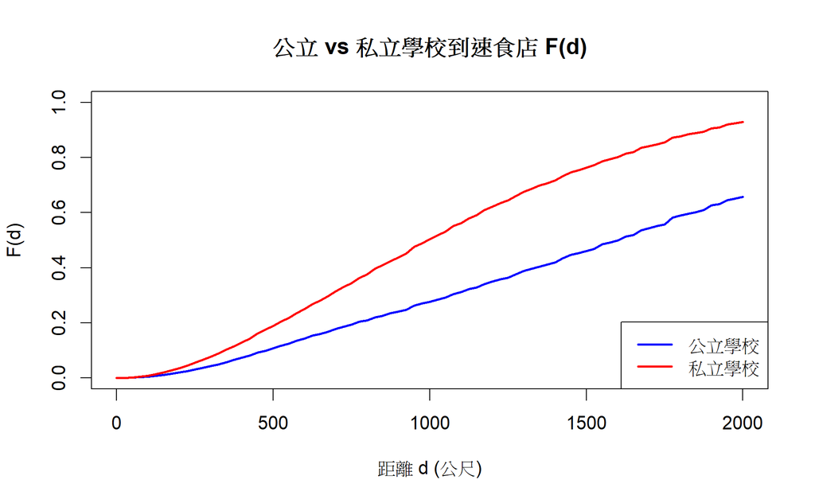

```r
legend("bottomright", legend = c("公立學校", "私立學校"),
       col = c("blue", "red"), lty = 1, lwd = 2)
```

```r
F_env_private <- envelope(pp_private, fun = Fest,
                          simulate = expression(runifpoint(pp_fastfood$n, win = win)),
                          nsim = 99, rank = 1,
                          correction = "rs", r = seq(0, 2000, by = 25))
```

```
Generating 99 simulations by evaluating expression  ...
1, 2, 3, 4, 5, 6, 7, 8, 9, 10, 11, 12, 13, 14, 15, 16, 17, 18, 19, 20, 21, 22, 23, 24, 25, 26, 27,
28, 29, 30, 31, 32, 33, 34, 35, 36, 37, 38, 39, 40, 41, 42, 43, 44, 45, 46, 47, 48, 49, 50, 51, 52, 53, 54,
55, 56, 57, 58, 59, 60, 61, 62, 63, 64, 65, 66, 67, 68, 69, 70, 71, 72, 73, 74, 75, 76, 77, 78, 79, 80, 81,
82, 83, 84, 85, 86, 87, 88, 89, 90, 91, 92, 93, 94, 95, 96, 97, 98,
99.

Done.
```

```r
F_env_public <- envelope(pp_public, fun = Fest,
                         simulate = expression(runifpoint(pp_fastfood$n, win = win)),
                         nsim = 99, rank = 1,
                         correction = "rs", r = seq(0, 2000, by = 25))
```

```
Generating 99 simulations by evaluating expression  ...
1, 2, 3, 4, 5, 6, 7, 8, 9, 10, 11, 12, 13, 14, 15, 16, 17, 18, 19, 20, 21, 22, 23, 24, 25, 26, 27,
28, 29, 30, 31, 32, 33, 34, 35, 36, 37, 38, 39, 40, 41, 42, 43, 44, 45, 46, 47, 48, 49, 50, 51, 52, 53, 54,
55, 56, 57, 58, 59, 60, 61, 62, 63, 64, 65, 66, 67, 68, 69, 70, 71, 72, 73, 74, 75, 76, 77, 78, 79, 80, 81,
82, 83, 84, 85, 86, 87, 88, 89, 90, 91, 92, 93, 94, 95, 96, 97, 98,
99.

Done.
```

```r
plot(F_env_private, main = "私立學校到速食店 F(d) 與 CSR 模擬 95% 信賴區間",
     xlab = "距離 d (公尺)", ylab = "F(d)", legend = FALSE)

lines(F_private$r, F_private$rs, col = "red", lwd = 2)
```

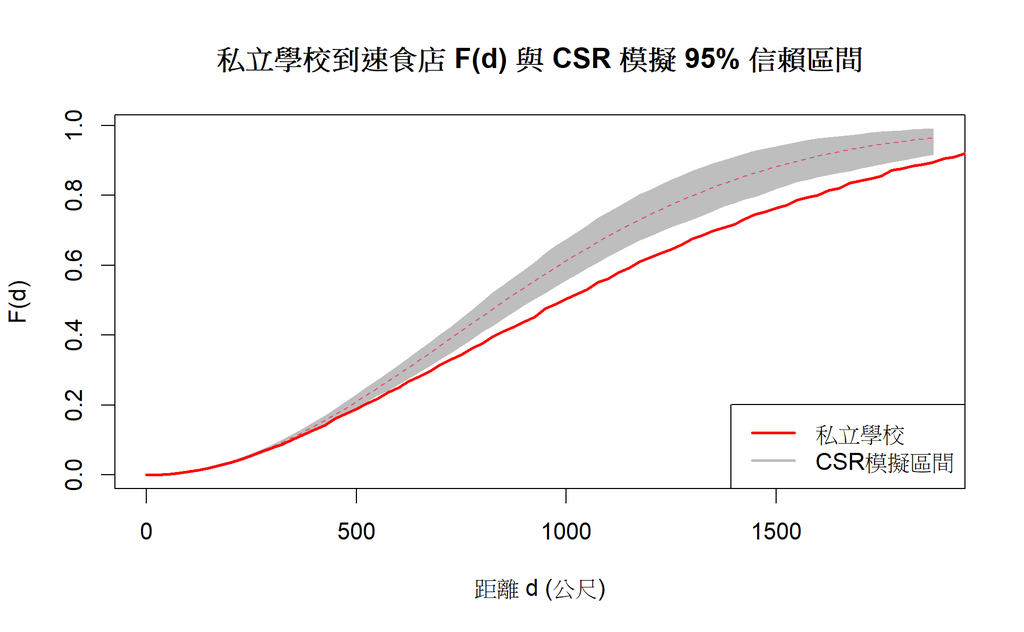

```r
legend("bottomright", legend = c("私立學校", "CSR模擬區間"),
       col = c("red", "gray"), lty = c(1,1,NA), lwd = 2)
```

```r
plot(F_env_public, main = "公立學校到速食店 F(d) 與 CSR 模擬 95% 信賴區間",
     xlab = "距離 d (公尺)", ylab = "F(d)", legend = FALSE)

lines(F_public$r, F_public$rs, col = "blue", lwd = 2)
```

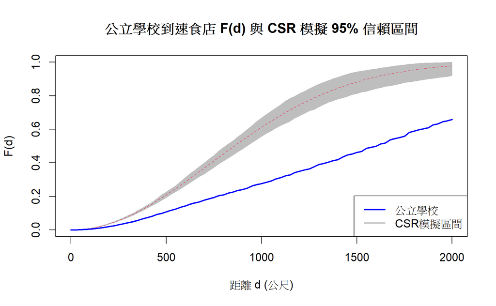

```r
legend("bottomright", legend = c("公立學校", "CSR模擬區間"),
       col = c("blue", "gray"), lty = c(1,1,NA), lwd = 2)
```

### Part3

##### 將 Vill_sf 合併為「臺北市整體邊界」

```r
Taipei_city <- Vill_sf %>%
  summarise(geometry = st_union(geometry)) %>%
  st_make_valid()
Taipei_city$COUNTY <- "臺北市"
```

##### school_sf增加COUNTY、TOWN、VILLAGE欄位

```r
school_data_joined <- st_join(school_data, Vill_sf, join = st_within)
school_sf2 <- school_data_joined %>%
  select(COUNTY,TOWN,VILLAGE,Type,Name,SID)
```

##### 將Vill_sf從村里層級，變成行政區層級

```r
TOWN_sf <- Vill_sf %>%
  group_by(TOWN) %>%
  summarise(geometry = st_union(geometry)) %>%
  ungroup() %>%
  st_make_valid()
TOWN_sf$COUNTY <- "臺北市"
TOWN_line <- TOWN_sf %>%
  st_cast("MULTILINESTRING")
```

##### STEP 1：計算每所學校的周邊速食店數量

```r
school_buff <- st_buffer(school_sf2, dist = 500)

# 計算每個學校 buffer 內有幾間速食店
school_ff <- st_join(school_buff, FF_sf, join = st_intersects) %>%
  group_by(Name) %>%
  summarise(ff_count = n()) %>%
  st_drop_geometry()

# 合併筆數進原始學校點
school_data <- school_sf2 %>%
  left_join(school_ff, by = "Name") %>%
  mutate(ff_count = replace_na(ff_count, 0))
```

##### STEP 2：建立鄰接矩陣（以學校為點位k-nearest neighbor）

```r
coords <- st_coordinates(st_centroid(school_data))

nb <- knn2nb(knearneigh(coords, k = 5))
lw <- nb2listw(nb, style = "W")
```

##### STEP 3：計算 Local G* 值（z-score）

```r
gi_star <- localG(school_data$ff_count, lw)

school_data$GiZ <- as.numeric(gi_star)
```

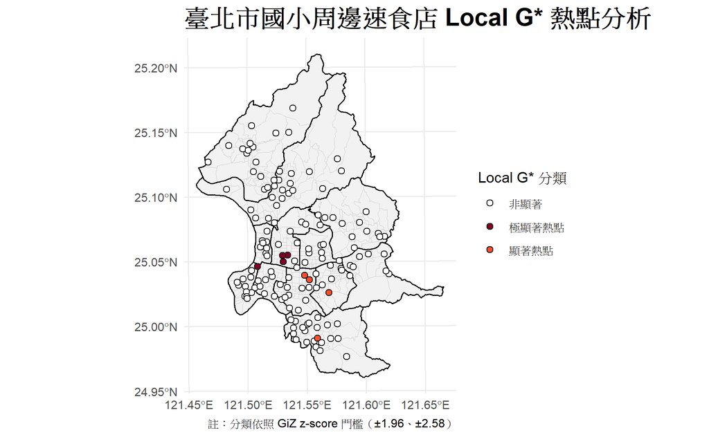

```r
# 確保 GiZ_class 分類完成
school_data <- school_data %>%
  mutate(GiZ_class = case_when(
    GiZ >= 2.58  ~ "極顯著熱點",  # p < 0.01
    GiZ >= 1.96  ~ "顯著熱點",    # p < 0.05
    GiZ <= -2.58 ~ "極顯著冷點",  # p < 0.01
    GiZ <= -1.96 ~ "顯著冷點",    # p < 0.05
    TRUE         ~ "非顯著"
  ))

# 畫出底圖 + 熱點分類地圖
ggplot() +
  geom_sf(data = Vill_sf, fill = "grey95", color = "grey80") +    # 行政區底圖


  geom_sf(data = school_data, aes(fill = GiZ_class), shape = 21, color = "black") +
  geom_sf(data = TOWN_line, color = "black", size = 0.5) +   # 加上邊界線
  theme_minimal()+

  geom_sf(data = school_data, aes(fill = GiZ_class), color = "black", size = 2, shape = 21) +
  scale_fill_manual(
    values = c(
      "極顯著熱點" = "#800026",
      "顯著熱點"   = "#FC4E2A",
      "非顯著"     = "white",
      "顯著冷點"   = "#2C7FB8",
      "極顯著冷點" = "#084081"
    ),
    name = "Local G* 分類"
  ) +
  labs(
    title = "臺北市國小周邊速食店 Local G* 熱點分析",
    caption = "註：分類依照 GiZ z-score 門檻（±1.96、±2.58）"
  ) +
  theme_minimal() +
  theme(
    plot.title = element_text(size = 18, face = "bold"),
    plot.subtitle = element_text(size = 14),
    legend.position = "right"
  )
```

```r
NA
NA
```

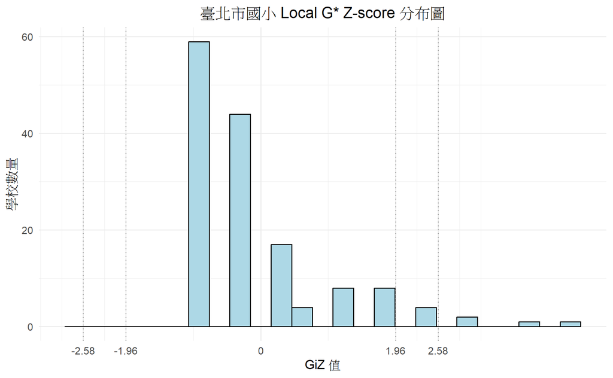

```r
ggplot(data.frame(GiZ = GiZ_vector), aes(x = GiZ)) +
  geom_histogram(binwidth = 0.3, fill = "lightblue", color = "black") +
  geom_vline(xintercept = c(-2.58, -1.96, 1.96, 2.58),
             color = "darkgray", linetype = "dotted") +
  scale_x_continuous(
    breaks = c(-2.58, -1.96, 0, 1.96, 2.58),
    labels = c("-2.58", "-1.96", "0", "1.96", "2.58")
  ) +
  labs(title = "臺北市國小 Local G* Z-score 分布圖",
       x = "GiZ 值", y = "學校數量") +
  theme_minimal()+
  theme(
    plot.title = element_text(hjust = 0.5)
  )
```